# Avaliação Continuada - Aula 9

**Execute a célula a seguir para importar as bibliotecas de que vamos precisar e criar a variável `titanic` com nossa base de dados.**

```python
# Importando a biblioteca seaborn
import seaborn as sns
import matplotlib.pyplot as plt

# Carregando a base de dados 'titanic'
titanic = sns.load_dataset("titanic")

titanic.head()
```

|  | survived | pclass | sex | age | sibsp | parch | fare | embarked | class | who | adult_male | deck | embark_town | alive | alone |
| --- | --- | --- | --- | --- | --- | --- | --- | --- | --- | --- | --- | --- | --- | --- | --- |
| 0 | 0 | 3 | male | 22.0 | 1 | 0 | 7.2500 | S | Third | man | True | NaN | Southampton | no | False |
| 1 | 1 | 1 | female | 38.0 | 1 | 0 | 71.2833 | C | First | woman | False | C | Cherbourg | yes | False |
| 2 | 1 | 3 | female | 26.0 | 0 | 0 | 7.9250 | S | Third | woman | False | NaN | Southampton | yes | True |
| 3 | 1 | 1 | female | 35.0 | 1 | 0 | 53.1000 | S | First | woman | False | C | Southampton | yes | False |
| 4 | 0 | 3 | male | 35.0 | 0 | 0 | 8.0500 | S | Third | man | True | NaN | Southampton | no | True |

### Sobre os dados

No exercício de hoje, vamos utilizar as variáveis:

- `fare`: indica o valor pago pela passagem, em dólares ($).
- `survived`: indica se o passageiro sobreviveu ao naufrágio, sendo 1 para sobreviveu e 0 para não sobreviveu.
- `embark_town`: indica a cidade onde o passageiro embarcou no navio.
- `sex`: indica o sexo do passageiro, sendo `male` para homens e `female` para mulheres.

### Exercício de hoje - Parte 1

No exercício de hoje estamos interessados em analisar apenas os passageiros do sexo feminino.

Utilize a função `query` para selecionar apenas as linhas da base de dados que correspondem a passageiros do sexo feminino (`sex == 'female'`).

Salve o resultado em uma variável chamada `titanic_female`.

```python
# continue o código abaixo
titanic_female = titanic
```

```python
# gabarito
titanic_female = titanic.query("sex == 'female'")
```

### Exercício de hoje - Parte 2

Seu trabalho hoje é modificar o gráfico abaixo explicando o achado de nossa análise.

Antes de executar as células abaixo você deve ter feito a parte 1 do exercício.

Vejamos primeiro esse gráfico:

```
[Text(0, 0, '75.1698'), Text(0, 0, '38.7409'), Text(0, 0, '12.635')]
```

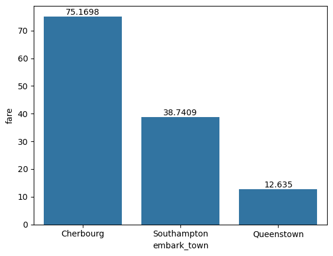

```python
fig, ax = plt.subplots()

sns.barplot(
    x="embark_town",
    y="fare",
    data=titanic_female,
    errorbar=None,
)

ax.bar_label(ax.containers[0])
```

Podemos ver o valor médio pago pelas passageiras que embarcaram em cada uma das cidades diferentes.

Há uma diferença considerável entre esses valores.

Vamos usar essa informação, mas sua tarefa vai ser alterar o gráfico abaixo sobre a proporção de sobreviventes que embarcaram e cada cidade para mencionar o valor da passagem:

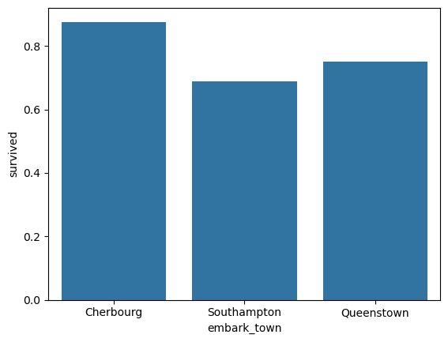

```python
sns.barplot(
    x="embark_town",
    y="survived",
    data=titanic_female,
    errorbar=None,
)
```

Sua tarefa é modificar o código abaixo para:

1. Adicionar um título e alterar o rótulo dos eixos do gráfico, explicando a informação dessas barras.
2. Adicione o texto `"Passageiras que embarcaram em Cherbough\npagaram o maior valor na médio na passagem\ne apresentaram a maior média de sobrevivência!"` usando a função `plt.text` para adicionar essa informação no gráfico. Sugerimos colocar o texto na posição `x=0.42` e `y=0.8`.

```python
t = "Passageiras que embarcaram em Cherbough\npagaram o maior valor na médio na passagem\ne apresentaram a maior média de sobrevivência!"
```

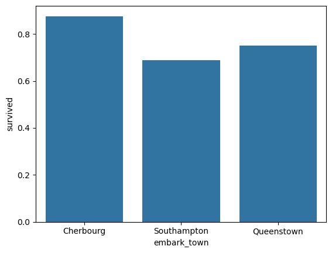

```python
fig, ax = plt.subplots()

sns.barplot(
    x="embark_town",
    y="survived",
    data=titanic_female,
    errorbar=None,
    ax=ax,
)

# adicione seu código abaixo
```

**Gabarito**

1. O conteúdo do título e eixos não é importante, desde que tenham sido alterados explicitamente.
2. Ao adicionar o texto o aluno pode usar `s=t`, como abaixo, ou escrever o texto novamente.

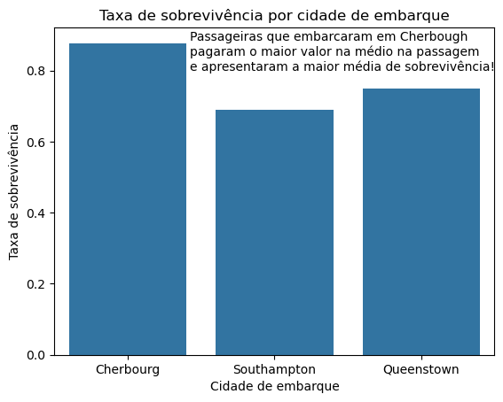

```python
fig, ax = plt.subplots()

sns.barplot(
    x="embark_town",
    y="survived",
    data=titanic_female,
    errorbar=None,
    ax=ax,
)

# adicione seu código abaixo
ax.set_title("Taxa de sobrevivência por cidade de embarque")
ax.set_xlabel("Cidade de embarque")
ax.set_ylabel("Taxa de sobrevivência")

ax.text(
    s=t,
    x=0.42,
    y=0.8
)
```